# Final assignment: Crime rate in Boston area

Pauliina Marjukka Anttila

pauliina.anttila@helsinki.fi

16 12 2017

# Abstract

**In my final assignment, I’ve studied a dataset about housing values in the suburbs of Boston. My hypotheses were that crime rate per capita is more often high in towns where the lower status of the population (percent) is more common and also in towns where property-tax rate is lower. Through logistic regression I found out that indeed, crime rate is more often high in tows where the lower status of population is more common (OR 1.21, CI 1.16-1.26). To my surprise, the crime rate was more often high in areas with higher property-tax rate.**

# Research question

**I’m going to study a dataset called ‘Boston’, which includes data about housing values in the suburbs of Boston. I’m going to concentrate especially on the crime rate of the towns.**

**My hypotheses are:**

**1) Crime rate per capita is higher in towns where full-value property-tax rate per $10,000 is lower.**

**2) Crime rate is more often high in towns where lower status of the population (percent) is more common.**

# Data wrangling

**Here’s a link to the data wrangling part of the final assignment:**

https://github.com/pauliinaanttila/IODS-final/blob/master/data_wrangling.R

# Description of the data and its variables

**I am working with a dataset called ‘Boston’ from the MASS package. The original dataset contains 506 observations of 14 variables. The dataset is about housing values in the suburbs of Boston.**

The original variables include the following:

crim = per capita crime rate by town.

zn = proportion of residential land zoned for lots over 25,000 sq.ft.

indus = proportion of non-retail business acres per town.

chas = Charles River dummy variable (= 1 if tract bounds river; 0 otherwise).

nox = nitrogen oxides concentration (parts per 10 million).

rm = average number of rooms per dwelling.

age = proportion of owner-occupied units built prior to 1940.

dis = weighted mean of distances to five Boston employment centres.

rad = index of accessibility to radial highways.

tax = full-value property-tax rate per $10,000.

ptratio = pupil-teacher ratio by town.

black = 1000(Bk - 0.63)^2 where Bk is the proportion of blacks by town.

lstat = lower status of the population (percent).

medv = median value of owner-occupied homes in $1000s.

During the data wrangling I created two new variables. The first one is ‘crime’, which is a catecorigal variable created from the ‘crim’ variable (4 categories (low, medium low, medium high, high), created using quantiles). The ‘crime_high’ variable is a binary variable, which was created from the ‘crime’ variable so that crime_high = TRUE is comparable ‘crime’ variable = 4 (the highest quantile).

```r
Boston_crime <- read.csv(file="~/Documents/GitHub/IODS-final/Boston_crime.csv", header = TRUE) # reading the wrangled data into R
str(Boston_crime) # exploring the structure of the data
```

```
## 'data.frame':    506 obs. of  16 variables:
##  $ crim      : num  0.00632 0.02731 0.02729 0.03237 0.06905 ...
##  $ zn        : num  18 0 0 0 0 0 12.5 12.5 12.5 12.5 ...
##  $ indus     : num  2.31 7.07 7.07 2.18 2.18 2.18 7.87 7.87 7.87 7.87 ...
##  $ chas      : int  0 0 0 0 0 0 0 0 0 0 ...
##  $ nox       : num  0.538 0.469 0.469 0.458 0.458 0.458 0.524 0.524 0.524 0.524 ...
##  $ rm        : num  6.58 6.42 7.18 7 7.15 ...
##  $ age       : num  65.2 78.9 61.1 45.8 54.2 58.7 66.6 96.1 100 85.9 ...
##  $ dis       : num  4.09 4.97 4.97 6.06 6.06 ...
##  $ rad       : int  1 2 2 3 3 3 5 5 5 5 ...
##  $ tax       : int  296 242 242 222 222 222 311 311 311 311 ...
##  $ ptratio   : num  15.3 17.8 17.8 18.7 18.7 18.7 15.2 15.2 15.2 15.2 ...
##  $ black     : num  397 397 393 395 397 ...
##  $ lstat     : num  4.98 9.14 4.03 2.94 5.33 ...
##  $ medv      : num  24 21.6 34.7 33.4 36.2 28.7 22.9 27.1 16.5 18.9 ...
##  $ crime     : Factor w/ 4 levels "high","low","med_high",..: 2 2 2 2 2 2 4 4 4 4 ...
##  $ crime_high: logi  FALSE FALSE FALSE FALSE FALSE FALSE ...
```

```r
dim(Boston_crime) # exploring the dimensions of the data
```

```
## [1] 506  16
```

# Exploration of the data

```r
summary(Boston_crime)
```

```
##       crim                zn             indus            chas
##  Min.   : 0.00632   Min.   :  0.00   Min.   : 0.46   Min.   :0.00000
##  1st Qu.: 0.08204   1st Qu.:  0.00   1st Qu.: 5.19   1st Qu.:0.00000
##  Median : 0.25651   Median :  0.00   Median : 9.69   Median :0.00000
##  Mean   : 3.61352   Mean   : 11.36   Mean   :11.14   Mean   :0.06917
##  3rd Qu.: 3.67708   3rd Qu.: 12.50   3rd Qu.:18.10   3rd Qu.:0.00000
##  Max.   :88.97620   Max.   :100.00   Max.   :27.74   Max.   :1.00000
##       nox               rm             age              dis
##  Min.   :0.3850   Min.   :3.561   Min.   :  2.90   Min.   : 1.130
##  1st Qu.:0.4490   1st Qu.:5.886   1st Qu.: 45.02   1st Qu.: 2.100
##  Median :0.5380   Median :6.208   Median : 77.50   Median : 3.207
##  Mean   :0.5547   Mean   :6.285   Mean   : 68.57   Mean   : 3.795
##  3rd Qu.:0.6240   3rd Qu.:6.623   3rd Qu.: 94.08   3rd Qu.: 5.188
##  Max.   :0.8710   Max.   :8.780   Max.   :100.00   Max.   :12.127
##       rad              tax           ptratio          black
##  Min.   : 1.000   Min.   :187.0   Min.   :12.60   Min.   :  0.32
##  1st Qu.: 4.000   1st Qu.:279.0   1st Qu.:17.40   1st Qu.:375.38
##  Median : 5.000   Median :330.0   Median :19.05   Median :391.44
##  Mean   : 9.549   Mean   :408.2   Mean   :18.46   Mean   :356.67
##  3rd Qu.:24.000   3rd Qu.:666.0   3rd Qu.:20.20   3rd Qu.:396.23
##  Max.   :24.000   Max.   :711.0   Max.   :22.00   Max.   :396.90
##      lstat            medv            crime     crime_high
##  Min.   : 1.73   Min.   : 5.00   high    :127   Mode :logical
##  1st Qu.: 6.95   1st Qu.:17.02   low     :127   FALSE:379
##  Median :11.36   Median :21.20   med_high:126   TRUE :127
##  Mean   :12.65   Mean   :22.53   med_low :126
##  3rd Qu.:16.95   3rd Qu.:25.00
##  Max.   :37.97   Max.   :50.00
```

**From the summary of the data, we can see that there are 127 observations with high crime rate (in the highest quantile). The per capita crime rate per town varies from 0.006-90.0 with the median of 0.26.**

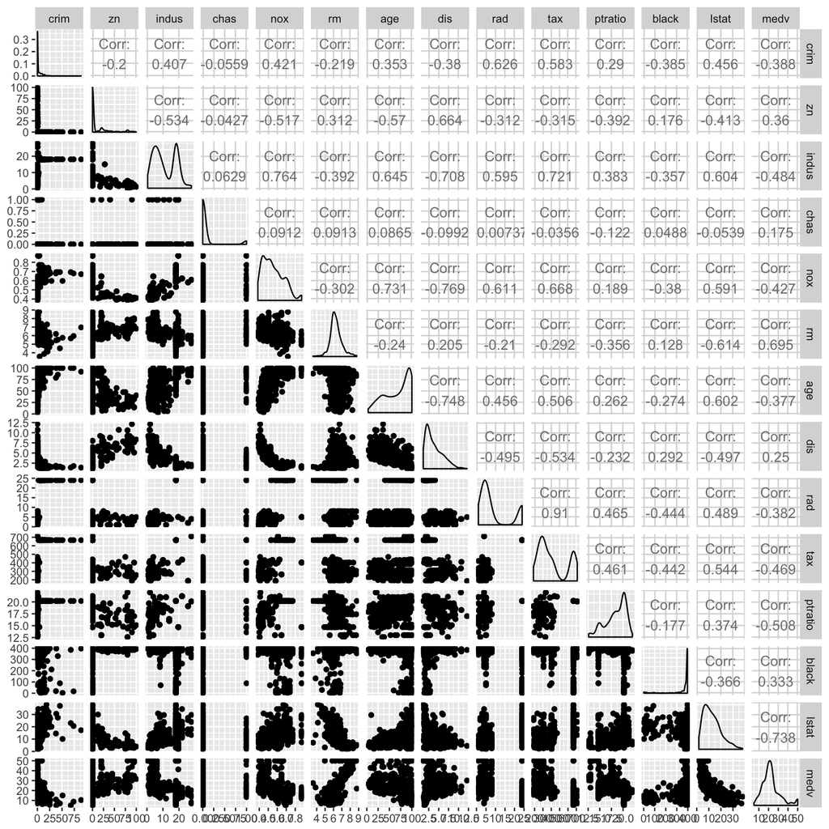

```r
library(MASS)
data("Boston")
library(GGally)
library(ggplot2)
ggpairs(Boston)
```

**This plot is created using the original ‘Boston’ dataset. According to the plot, there seems to be a positive correlation between crime rate and lower status of the population. There is also a positive correlation between the tax variable (full-value property-tax rate per $10,000) and crime rate.**

```r
# Creating a correlation plot from the original 'Boston' data (contains only numeric variables):

library(dplyr)
library(corrplot)
cor_matrix<-cor(Boston) %>% round(2)
cor_matrix
```

```
##          crim    zn indus  chas   nox    rm   age   dis   rad   tax
## crim     1.00 -0.20  0.41 -0.06  0.42 -0.22  0.35 -0.38  0.63  0.58
## zn      -0.20  1.00 -0.53 -0.04 -0.52  0.31 -0.57  0.66 -0.31 -0.31
## indus    0.41 -0.53  1.00  0.06  0.76 -0.39  0.64 -0.71  0.60  0.72
## chas    -0.06 -0.04  0.06  1.00  0.09  0.09  0.09 -0.10 -0.01 -0.04
## nox      0.42 -0.52  0.76  0.09  1.00 -0.30  0.73 -0.77  0.61  0.67
## rm      -0.22  0.31 -0.39  0.09 -0.30  1.00 -0.24  0.21 -0.21 -0.29
## age      0.35 -0.57  0.64  0.09  0.73 -0.24  1.00 -0.75  0.46  0.51
## dis     -0.38  0.66 -0.71 -0.10 -0.77  0.21 -0.75  1.00 -0.49 -0.53
## rad      0.63 -0.31  0.60 -0.01  0.61 -0.21  0.46 -0.49  1.00  0.91
## tax      0.58 -0.31  0.72 -0.04  0.67 -0.29  0.51 -0.53  0.91  1.00
## ptratio  0.29 -0.39  0.38 -0.12  0.19 -0.36  0.26 -0.23  0.46  0.46
## black   -0.39  0.18 -0.36  0.05 -0.38  0.13 -0.27  0.29 -0.44 -0.44
## lstat    0.46 -0.41  0.60 -0.05  0.59 -0.61  0.60 -0.50  0.49  0.54
## medv    -0.39  0.36 -0.48  0.18 -0.43  0.70 -0.38  0.25 -0.38 -0.47
##         ptratio black lstat  medv
## crim       0.29 -0.39  0.46 -0.39
## zn        -0.39  0.18 -0.41  0.36
## indus      0.38 -0.36  0.60 -0.48
## chas      -0.12  0.05 -0.05  0.18
## nox        0.19 -0.38  0.59 -0.43
## rm        -0.36  0.13 -0.61  0.70
## age        0.26 -0.27  0.60 -0.38
## dis       -0.23  0.29 -0.50  0.25
## rad        0.46 -0.44  0.49 -0.38
## tax        0.46 -0.44  0.54 -0.47
## ptratio    1.00 -0.18  0.37 -0.51
## black     -0.18  1.00 -0.37  0.33
## lstat      0.37 -0.37  1.00 -0.74
## medv      -0.51  0.33 -0.74  1.00
```

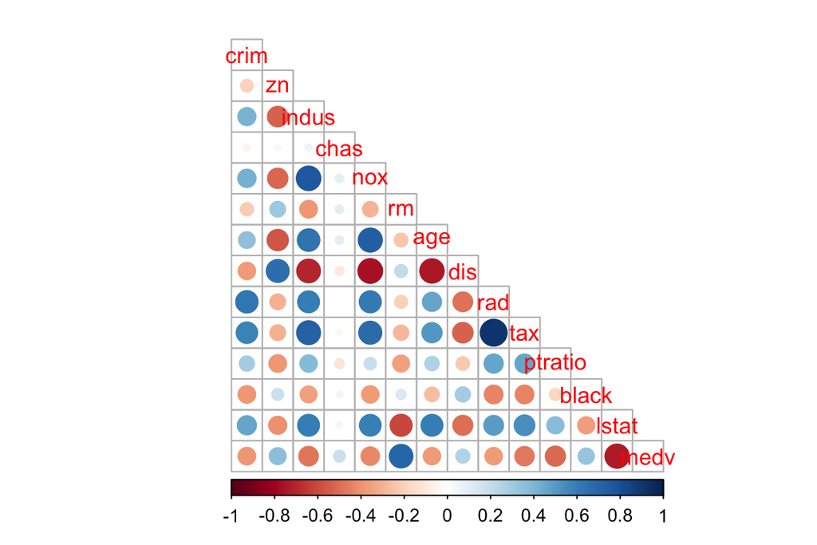

```r
corrplot(cor_matrix, method="circle", type = "lower", cl.pos = "b", tl.pos = "d", tl.cex = 1.0)
```

**According to the correlation plot, crime rate per capita by town is positively correlated with the variables ‘tax’ and ‘lstat’. According to the correlation plot, there is going to be collinearity between ‘tax’ and ‘lstat’, that is why I’m going to do the logistic regression with both separately and also togehter.**

# Brief description of logistic regression

**I am going to examine the association between high crime rate, and property-tax rate and lower status of the population. I’m going to use a statistical method called logistic regression. Logistic regression is a regression model where the dependent variable is categorical. Like all regression analyses, the logistic regression is a predictive analysis. Logistic regression is used to describe data and to explain the relationship between one dependent binary variable and one or more nominal, ordinal, interval or ratio-level independent variables.**

# Results

**A logistic regression model with the dependent variable being ‘crime_high’ (a binominal variable) and the explanatory variables being ‘tax’ and ‘lstat’:**

```r
model1 <- glm(formula = crime_high ~ tax + lstat, data = Boston_crime, family = "binomial")
summary(model1)
```

```
##
## Call:
## glm(formula = crime_high ~ tax + lstat, family = "binomial",
##     data = Boston_crime)
##
## Deviance Residuals:
##      Min        1Q    Median        3Q       Max
## -3.04762  -0.05742  -0.02713   0.12114   2.57004
##
## Coefficients:
##               Estimate Std. Error z value Pr(>|z|)
## (Intercept) -15.684073   2.156884  -7.272 3.55e-13 ***
## tax           0.024652   0.003101   7.951 1.85e-15 ***
## lstat         0.094026   0.044202   2.127   0.0334 *
## ---
## Signif. codes:  0 '***' 0.001 '**' 0.01 '*' 0.05 '.' 0.1 ' ' 1
##
## (Dispersion parameter for binomial family taken to be 1)
##
##     Null deviance: 570.179  on 505  degrees of freedom
## Residual deviance:  95.146  on 503  degrees of freedom
## AIC: 101.15
##
## Number of Fisher Scoring iterations: 8
```

```r
coef(model1)
```

```
## (Intercept)         tax       lstat
## -15.6840727   0.0246522   0.0940259
```

```r
OR <- coef(model1) %>% exp
CI <- confint(model1) %>% exp # calculating the odds ratios and confidence intervals
cbind(OR, CI)
```

```
##                       OR        2.5 %       97.5 %
## (Intercept) 1.543454e-07 7.690240e-10 5.028796e-06
## tax         1.024959e+00 1.019741e+00 1.032825e+00
## lstat       1.098588e+00 1.009173e+00 1.201311e+00
```

**Accoring to the model, crime rate seems to be more often high in areas with higher tax rate for properties (odds ratio 1.025, confidence interval 1.020-1.033). The crime rate is more often high in areas with lower status of the population (OR 1.099, CI 1.009-1.201).**

```r
model2 <- glm(formula = crime_high ~ tax, data = Boston_crime, family = "binomial")
summary(model2)
```

```
##
## Call:
## glm(formula = crime_high ~ tax, family = "binomial", data = Boston_crime)
##
## Deviance Residuals:
##      Min        1Q    Median        3Q       Max
## -2.64656  -0.06415  -0.03363   0.32042   2.94886
##
## Coefficients:
##               Estimate Std. Error z value Pr(>|z|)
## (Intercept) -14.549125   1.917452  -7.588 3.26e-14 ***
## tax           0.025346   0.003015   8.406  < 2e-16 ***
## ---
## Signif. codes:  0 '***' 0.001 '**' 0.01 '*' 0.05 '.' 0.1 ' ' 1
##
## (Dispersion parameter for binomial family taken to be 1)
##
##     Null deviance: 570.179  on 505  degrees of freedom
## Residual deviance:  99.877  on 504  degrees of freedom
## AIC: 103.88
##
## Number of Fisher Scoring iterations: 8
```

```r
coef(model2)
```

```
##  (Intercept)          tax
## -14.54912484   0.02534554
```

```r
OR2 <- coef(model2) %>% exp
CI2 <- confint(model2) %>% exp # calculating the odds ratios and confidence intervals
cbind(OR2, CI2)
```

```
##                      OR2        2.5 %       97.5 %
## (Intercept) 4.801704e-07 3.660242e-09 1.031206e-05
## tax         1.025669e+00 1.020611e+00 1.033387e+00
```

**In this model as well, higher property tax-rate is associated with higher crime rate.**

```r
model3 <- glm(formula = crime_high ~ lstat, data = Boston_crime, family = "binomial")
summary(model3)
```

```
##
## Call:
## glm(formula = crime_high ~ lstat, family = "binomial", data = Boston_crime)
##
## Deviance Residuals:
##     Min       1Q   Median       3Q      Max
## -2.3490  -0.6306  -0.4114   0.1333   2.5537
##
## Coefficients:
##             Estimate Std. Error z value Pr(>|z|)
## (Intercept) -3.77819    0.31928 -11.834   <2e-16 ***
## lstat        0.18807    0.01948   9.652   <2e-16 ***
## ---
## Signif. codes:  0 '***' 0.001 '**' 0.01 '*' 0.05 '.' 0.1 ' ' 1
##
## (Dispersion parameter for binomial family taken to be 1)
##
##     Null deviance: 570.18  on 505  degrees of freedom
## Residual deviance: 434.33  on 504  degrees of freedom
## AIC: 438.33
##
## Number of Fisher Scoring iterations: 5
```

```r
coef(model3)
```

```
## (Intercept)       lstat
##  -3.7781944   0.1880721
```

```r
OR3 <- coef(model3) %>% exp
CI3 <- confint(model3) %>% exp # calculating the odds ratios and confidence intervals
cbind(OR3, CI3)
```

```
##                    OR3      2.5 %    97.5 %
## (Intercept) 0.02286394 0.01186142 0.0415846
## lstat       1.20692054 1.16350364 1.2560687
```

**In this model with the lower status of the population being the only explanatory variable, the odds ratio is higher (OR 1.207, CI 1.164-1.256) than in the first analysis with the two explanatory variables.**

# Conclusions and discussion

**Lower status of population is associated with crime rate so that every 1 % rise in the proportion of lower status people raises the odds for high crime rate with 10-21 % (depending on the logistic model used).**